# Supervised Learning - Foundations Project: ReCell

## Problem Statement

### Business Context

Buying and selling used phones and tablets used to be something that happened on a handful of online marketplace sites. But the used and refurbished device market has grown considerably over the past decade, and a new IDC (International Data Corporation) forecast predicts that the used phone market would be worth \$52.7bn by 2023 with a compound annual growth rate (CAGR) of 13.6% from 2018 to 2023. This growth can be attributed to an uptick in demand for used phones and tablets that offer considerable savings compared with new models.

Refurbished and used devices continue to provide cost-effective alternatives to both consumers and businesses that are looking to save money when purchasing one. There are plenty of other benefits associated with the used device market. Used and refurbished devices can be sold with warranties and can also be insured with proof of purchase. Third-party vendors/platforms, such as Verizon, Amazon, etc., provide attractive offers to customers for refurbished devices. Maximizing the longevity of devices through second-hand trade also reduces their environmental impact and helps in recycling and reducing waste. The impact of the COVID-19 outbreak may further boost this segment as consumers cut back on discretionary spending and buy phones and tablets only for immediate needs.

### Objective

The rising potential of this comparatively under-the-radar market fuels the need for an ML-based solution to develop a dynamic pricing strategy for used and refurbished devices. ReCell, a startup aiming to tap the potential in this market, has hired you as a data scientist. They want you to analyze the data provided and build a linear regression model to predict the price of a used phone/tablet and identify factors that significantly influence it.

### Data Description

The data contains the different attributes of used/refurbished phones and tablets. The data was collected in the year 2021. The detailed data dictionary is given below.

- brand_name: Name of manufacturing brand
- os: OS on which the device runs
- screen_size: Size of the screen in cm
- 4g: Whether 4G is available or not
- 5g: Whether 5G is available or not
- main_camera_mp: Resolution of the rear camera in megapixels
- selfie_camera_mp: Resolution of the front camera in megapixels
- int_memory: Amount of internal memory (ROM) in GB
- ram: Amount of RAM in GB
- battery: Energy capacity of the device battery in mAh
- weight: Weight of the device in grams
- release_year: Year when the device model was released
- days_used: Number of days the used/refurbished device has been used
- normalized_new_price: Normalized price of a new device of the same model in euros
- normalized_used_price: Normalized price of the used/refurbished device in euros

## Importing necessary libraries

```python
!pip install nb_black
```

```python
# this will help in making the Python code more structured automatically (good coding practice)
%load_ext nb_black

# Libraries to help with reading and manipulating data
import numpy as np
import pandas as pd

# Libraries to help with data visualization
import matplotlib.pyplot as plt
import seaborn as sns

sns.set()

# split the data into train and test
from sklearn.model_selection import train_test_split

# to build linear regression_model
from sklearn.linear_model import LinearRegression

# to check model performance
from sklearn.metrics import mean_absolute_error, mean_squared_error, r2_score

# to build linear regression_model using statsmodels
import statsmodels.api as sm

# to compute VIF
from statsmodels.stats.outliers_influence import variance_inflation_factor
```

## Loading the dataset

```python
data = pd.read_csv("/Users/camilaconyers/Downloads/used_device_data.csv")
```

## Data Overview

- Observations
- Sanity checks

### Displaying the first 5 rows of the dataset

```python
data.head()
```

|  | brand_name | os | screen_size | 4g | 5g | main_camera_mp | selfie_camera_mp | int_memory | ram | battery | weight | release_year | days_used | normalized_used_price | normalized_new_price |
| --- | --- | --- | --- | --- | --- | --- | --- | --- | --- | --- | --- | --- | --- | --- | --- |
| 0 | Honor | Android | 14.50 | yes | no | 13.0 | 5.0 | 64.0 | 3.0 | 3020.0 | 146.0 | 2020 | 127 | 4.307572 | 4.715100 |
| 1 | Honor | Android | 17.30 | yes | yes | 13.0 | 16.0 | 128.0 | 8.0 | 4300.0 | 213.0 | 2020 | 325 | 5.162097 | 5.519018 |
| 2 | Honor | Android | 16.69 | yes | yes | 13.0 | 8.0 | 128.0 | 8.0 | 4200.0 | 213.0 | 2020 | 162 | 5.111084 | 5.884631 |
| 3 | Honor | Android | 25.50 | yes | yes | 13.0 | 8.0 | 64.0 | 6.0 | 7250.0 | 480.0 | 2020 | 345 | 5.135387 | 5.630961 |
| 4 | Honor | Android | 15.32 | yes | no | 13.0 | 8.0 | 64.0 | 3.0 | 5000.0 | 185.0 | 2020 | 293 | 4.389995 | 4.947837 |

### Checking the shape of the dataset

```python
data.shape
```

```
(3454, 15)
```

### Checking the data types of the columns for the dataset

```python
data.info()
```

```
<class 'pandas.core.frame.DataFrame'>
RangeIndex: 3454 entries, 0 to 3453
Data columns (total 15 columns):
 #   Column                 Non-Null Count  Dtype
---  ------                 --------------  -----
 0   brand_name             3454 non-null   object
 1   os                     3454 non-null   object
 2   screen_size            3454 non-null   float64
 3   4g                     3454 non-null   object
 4   5g                     3454 non-null   object
 5   main_camera_mp         3275 non-null   float64
 6   selfie_camera_mp       3452 non-null   float64
 7   int_memory             3450 non-null   float64
 8   ram                    3450 non-null   float64
 9   battery                3448 non-null   float64
 10  weight                 3447 non-null   float64
 11  release_year           3454 non-null   int64
 12  days_used              3454 non-null   int64
 13  normalized_used_price  3454 non-null   float64
 14  normalized_new_price   3454 non-null   float64
dtypes: float64(9), int64(2), object(4)
memory usage: 404.9+ KB
```

### Statistical summary of the dataset

```python
data.describe().T
```

|  | count | mean | std | min | 25% | 50% | 75% | max |
| --- | --- | --- | --- | --- | --- | --- | --- | --- |
| screen_size | 3454.0 | 13.713115 | 3.805280 | 5.080000 | 12.700000 | 12.830000 | 15.340000 | 30.710000 |
| main_camera_mp | 3275.0 | 9.460208 | 4.815461 | 0.080000 | 5.000000 | 8.000000 | 13.000000 | 48.000000 |
| selfie_camera_mp | 3452.0 | 6.554229 | 6.970372 | 0.000000 | 2.000000 | 5.000000 | 8.000000 | 32.000000 |
| int_memory | 3450.0 | 54.573099 | 84.972371 | 0.010000 | 16.000000 | 32.000000 | 64.000000 | 1024.000000 |
| ram | 3450.0 | 4.036122 | 1.365105 | 0.020000 | 4.000000 | 4.000000 | 4.000000 | 12.000000 |
| battery | 3448.0 | 3133.402697 | 1299.682844 | 500.000000 | 2100.000000 | 3000.000000 | 4000.000000 | 9720.000000 |
| weight | 3447.0 | 182.751871 | 88.413228 | 69.000000 | 142.000000 | 160.000000 | 185.000000 | 855.000000 |
| release_year | 3454.0 | 2015.965258 | 2.298455 | 2013.000000 | 2014.000000 | 2015.500000 | 2018.000000 | 2020.000000 |
| days_used | 3454.0 | 674.869716 | 248.580166 | 91.000000 | 533.500000 | 690.500000 | 868.750000 | 1094.000000 |
| normalized_used_price | 3454.0 | 4.364712 | 0.588914 | 1.536867 | 4.033931 | 4.405133 | 4.755700 | 6.619433 |
| normalized_new_price | 3454.0 | 5.233107 | 0.683637 | 2.901422 | 4.790342 | 5.245892 | 5.673718 | 7.847841 |

### Checking for duplicate values

```python
data.duplicated()
```

```
0       False
1       False
2       False
3       False
4       False
        ...
3449    False
3450    False
3451    False
3452    False
3453    False
Length: 3454, dtype: bool
```

### Checking for missing values

```python
data.isnull().sum()
```

```
brand_name                 0
os                         0
screen_size                0
4g                         0
5g                         0
main_camera_mp           179
selfie_camera_mp           2
int_memory                 4
ram                        4
battery                    6
weight                     7
release_year               0
days_used                  0
normalized_used_price      0
normalized_new_price       0
dtype: int64
```

```python
# creating a copy of the data so that original data remains unchanged
df = data.copy()
```

## Exploratory Data Analysis (EDA)

- EDA is an important part of any project involving data.
- It is important to investigate and understand the data better before building a model with it.
- A few questions have been mentioned below which will help you approach the analysis in the right manner and generate insights from the data.
- A thorough analysis of the data, in addition to the questions mentioned below, should be done.

**Questions**:

1. What does the distribution of normalized used device prices look like?
2. What percentage of the used device market is dominated by Android devices?
3. The amount of RAM is important for the smooth functioning of a device. How does the amount of RAM vary with the brand?
4. A large battery often increases a device's weight, making it feel uncomfortable in the hands. How does the weight vary for phones and tablets offering large batteries (more than 4500 mAh)?
5. Bigger screens are desirable for entertainment purposes as they offer a better viewing experience. How many phones and tablets are available across different brands with a screen size larger than 6 inches?
6. A lot of devices nowadays offer great selfie cameras, allowing us to capture our favorite moments with loved ones. What is the distribution of devices offering greater than 8MP selfie cameras across brands?
7. Which attributes are highly correlated with the normalized price of a used device?

```python
# function to plot a boxplot and a histogram along the same scale.


def histogram_boxplot(data, feature, figsize=(15, 10), kde=False, bins=None):
    """
    Boxplot and histogram combined

    data: dataframe
    feature: dataframe column
    figsize: size of figure (default (15,10))
    kde: whether to show the density curve (default False)
    bins: number of bins for histogram (default None)
    """
    f2, (ax_box2, ax_hist2) = plt.subplots(
        nrows=2,  # Number of rows of the subplot grid= 2
        sharex=True,  # x-axis will be shared among all subplots
        gridspec_kw={"height_ratios": (0.25, 0.75)},
        figsize=figsize,
    )  # creating the 2 subplots
    sns.boxplot(
        data=data, x=feature, ax=ax_box2, showmeans=True, color="violet"
    )  # boxplot will be created and a triangle will indicate the mean value of the column
    sns.histplot(
        data=data, x=feature, kde=kde, ax=ax_hist2, bins=bins
    ) if bins else sns.histplot(
        data=data, x=feature, kde=kde, ax=ax_hist2
    )  # For histogram
    ax_hist2.axvline(
        data[feature].mean(), color="green", linestyle="--"
    )  # Add mean to the histogram
    ax_hist2.axvline(
        data[feature].median(), color="black", linestyle="-"
    )  # Add median to the histogram
```

```python
# function to create labeled barplots


def labeled_barplot(data, feature, perc=False, n=None):
    """
    Barplot with percentage at the top

    data: dataframe
    feature: dataframe column
    perc: whether to display percentages instead of count (default is False)
    n: displays the top n category levels (default is None, i.e., display all levels)
    """

    total = len(data[feature])  # length of the column
    count = data[feature].nunique()
    if n is None:
        plt.figure(figsize=(count + 2, 6))
    else:
        plt.figure(figsize=(n + 2, 6))

    plt.xticks(rotation=90, fontsize=15)
    ax = sns.countplot(
        data=data,
        x=feature,
        palette="Paired",
        order=data[feature].value_counts().index[:n],
    )

    for p in ax.patches:
        if perc == True:
            label = "{:.1f}%".format(
                100 * p.get_height() / total
            )  # percentage of each class of the category
        else:
            label = p.get_height()  # count of each level of the category

        x = p.get_x() + p.get_width() / 2  # width of the plot
        y = p.get_height()  # height of the plot

        ax.annotate(
            label,
            (x, y),
            ha="center",
            va="center",
            size=12,
            xytext=(0, 5),
            textcoords="offset points",
        )  # annotate the percentage

    plt.show()  # show the plot
```

**`normalized_used_price`**

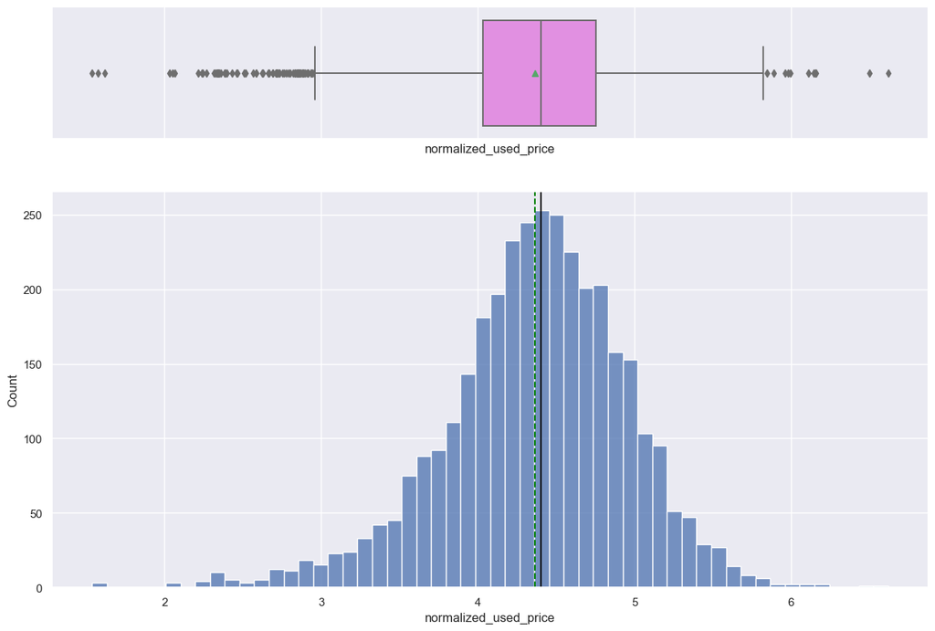

```python
histogram_boxplot(df, "normalized_used_price")
```

**`normalized_new_price`**

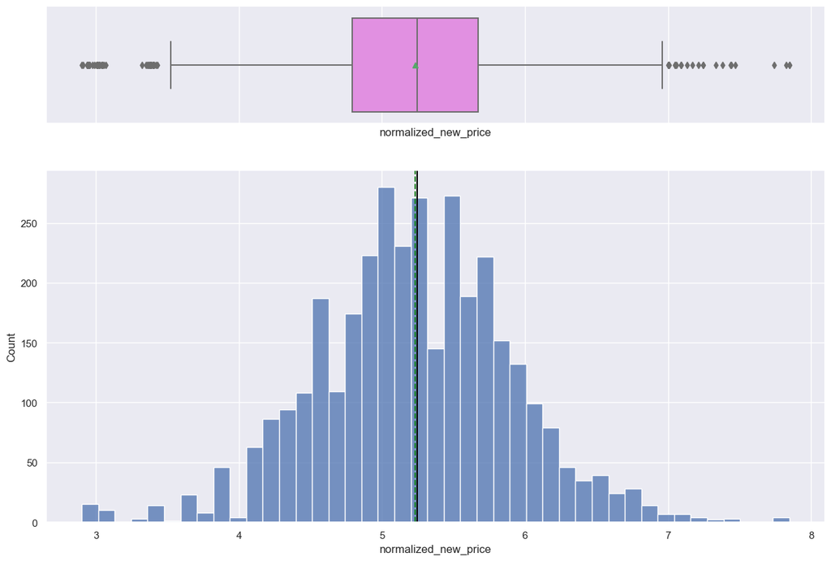

```python
histogram_boxplot(df, "normalized_new_price")
```

**`screen_size`**

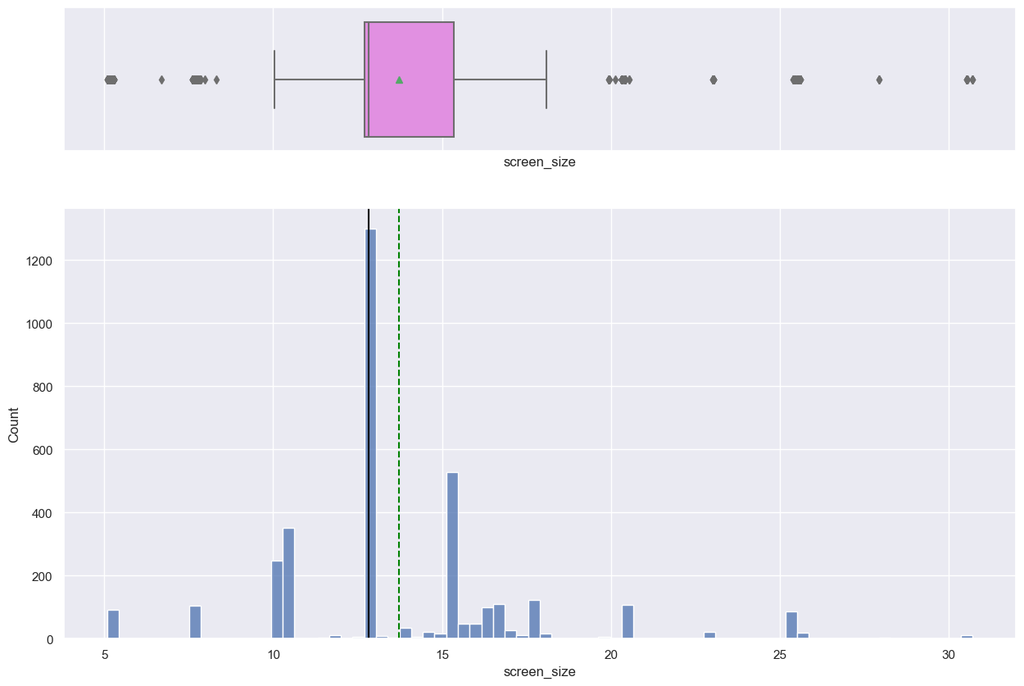

```python
histogram_boxplot(df, "screen_size")
```

**`main_camera_mp`**

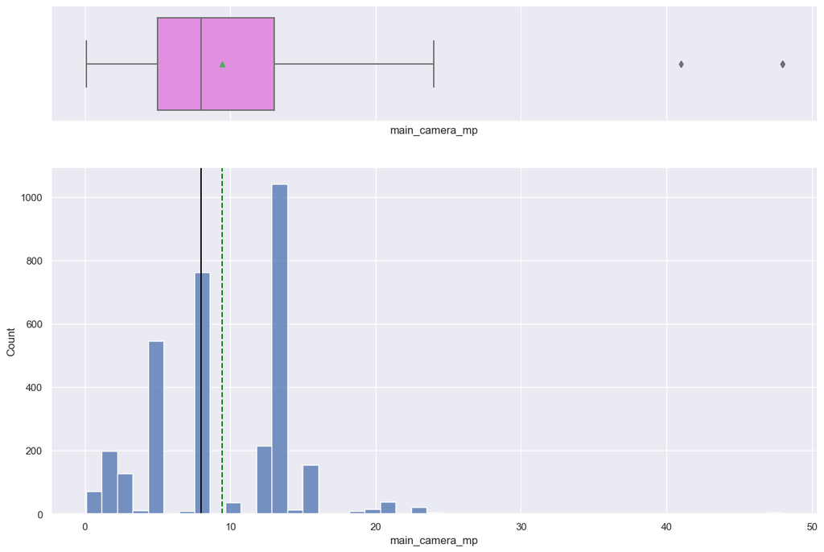

```python
histogram_boxplot(df, "main_camera_mp")
```

**`selfie_camera_mp`**

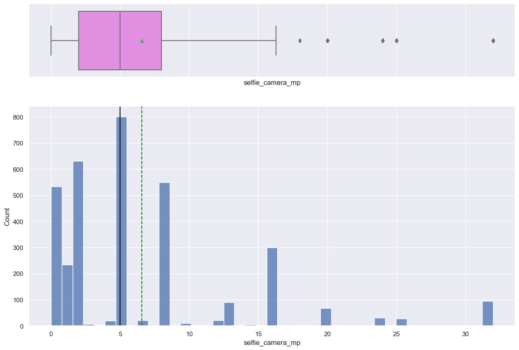

```python
histogram_boxplot(df, "selfie_camera_mp")
```

**`int_memory`**

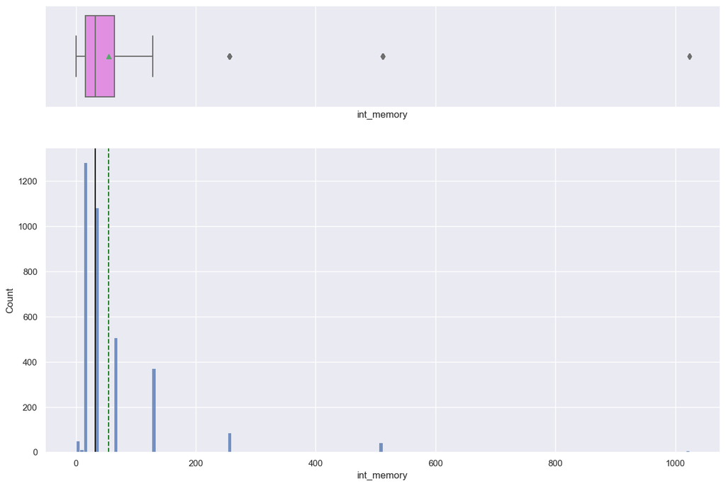

```python
histogram_boxplot(df, "int_memory")
```

**`ram`**

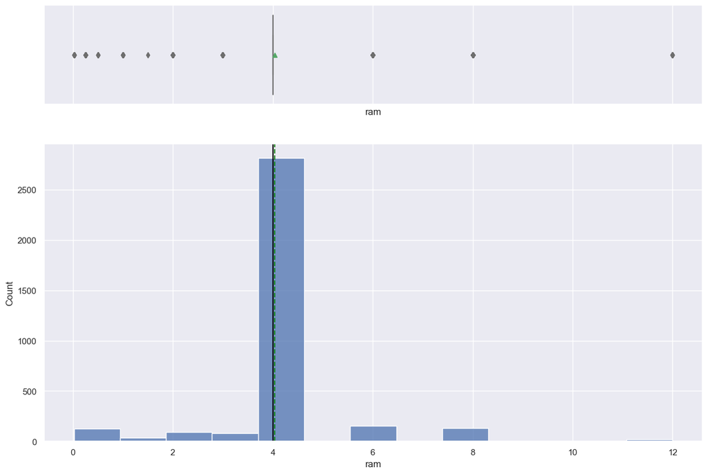

```python
histogram_boxplot(df, "ram")
```

**`weight`**

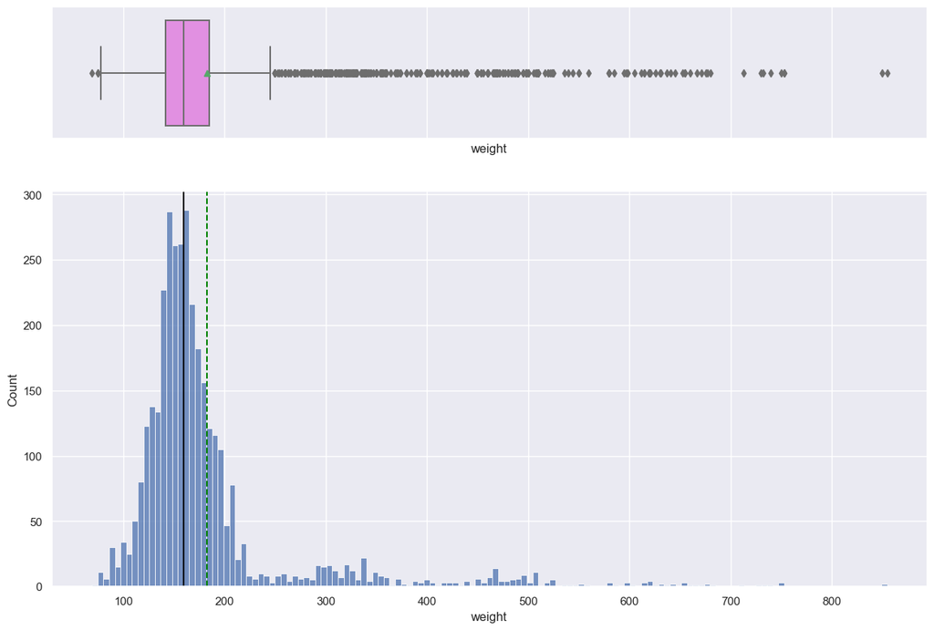

```python
histogram_boxplot(df, "weight")
```

**`battery`**

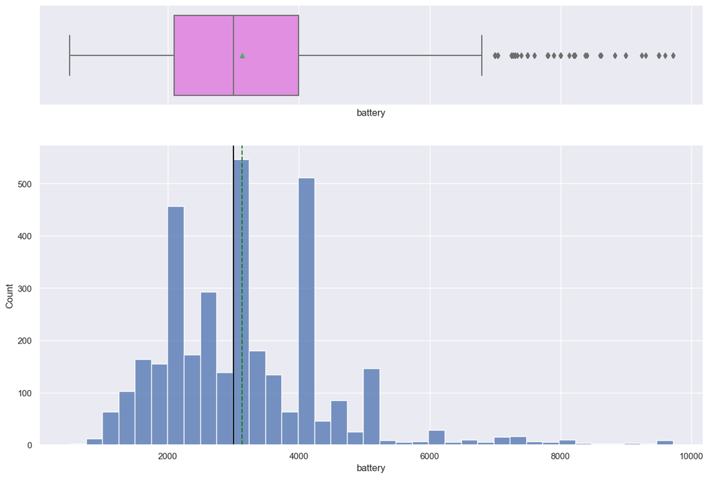

```python
histogram_boxplot(df, "battery")
```

**`days_used`**

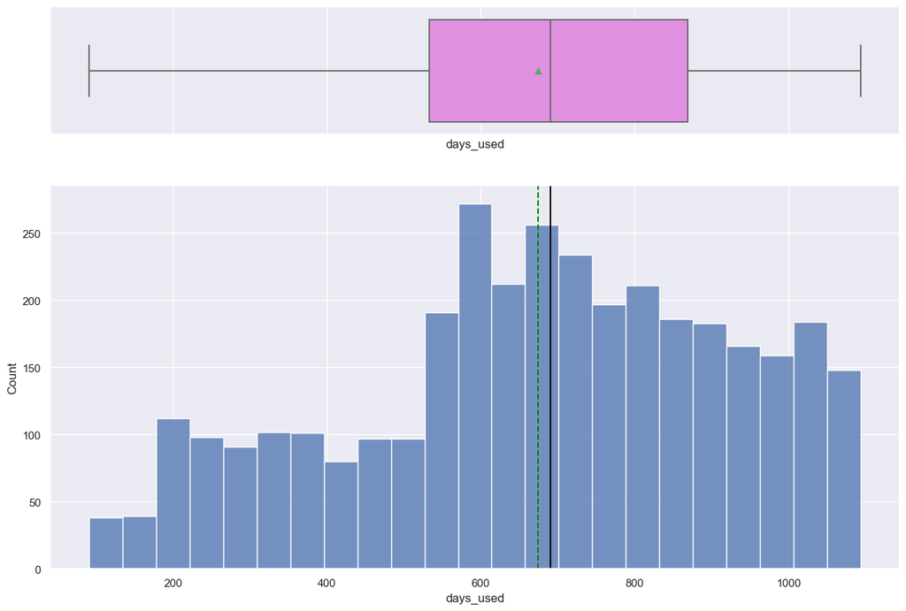

```python
histogram_boxplot(df, "days_used")
```

**`brand_name`**

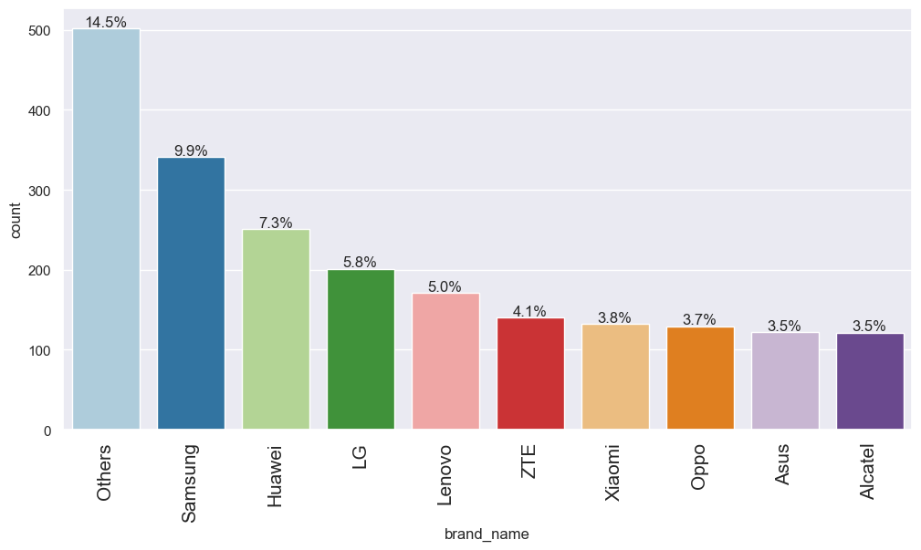

```python
labeled_barplot(df, "brand_name", perc=True, n=10)
```

**`os`**

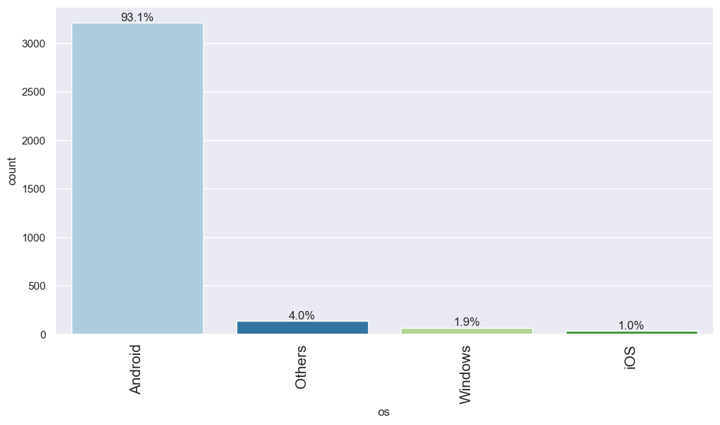

```python
labeled_barplot(df, "os", perc=True, n=10)
```

**`4g`**

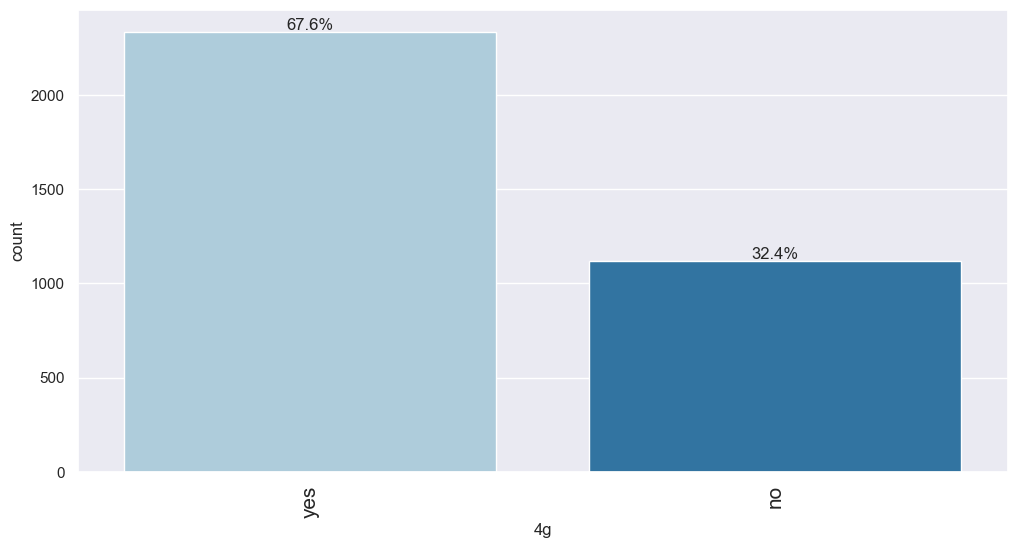

```python
labeled_barplot(df, "4g", perc=True, n=10)
```

**`5g`**

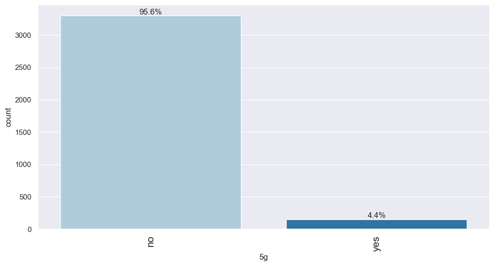

```python
labeled_barplot(df, "5g", perc=True, n=10)
```

**`release_year`**

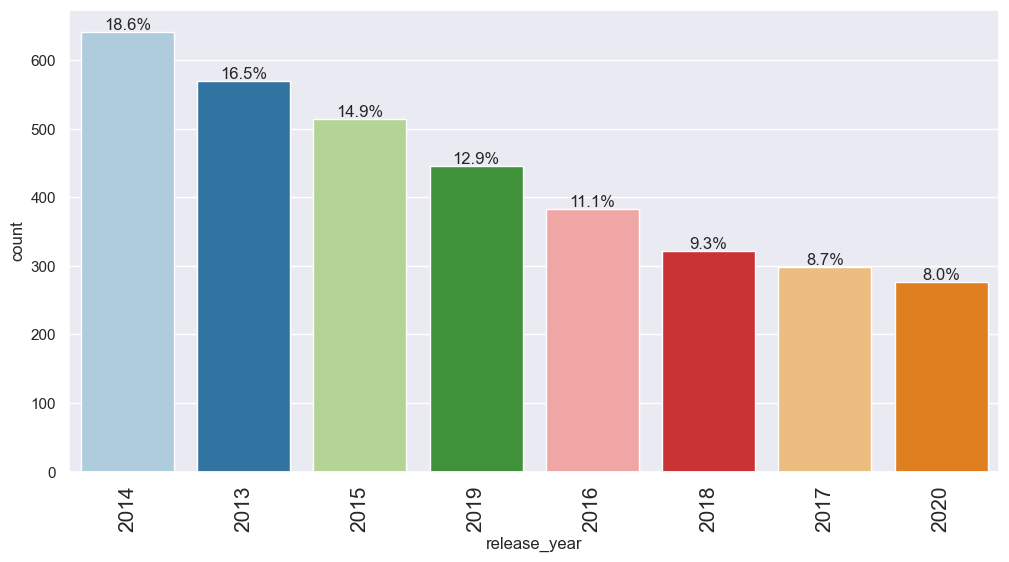

```python
labeled_barplot(df, "release_year", perc=True, n=10)
```

### Bivariate Analysis

**Correlation Check**

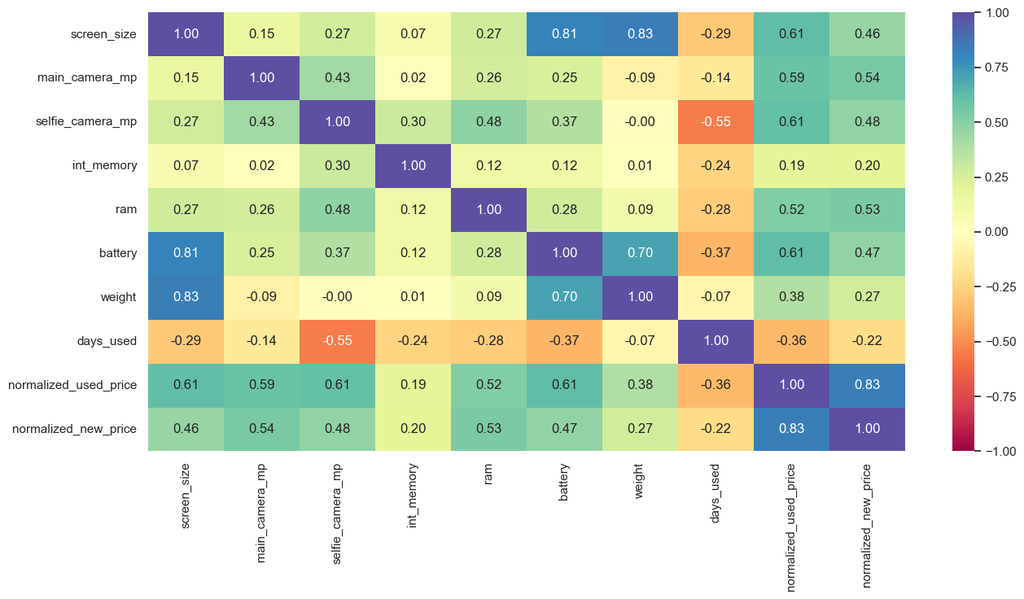

```python
cols_list = df.select_dtypes(include=np.number).columns.tolist()
# dropping release_year as it is a temporal variable
cols_list.remove("release_year")

plt.figure(figsize=(15, 7))
sns.heatmap(
    df[cols_list].corr(), annot=True, vmin=-1, vmax=1, fmt=".2f", cmap="Spectral"
)
plt.show()
```

**The amount of RAM is important for the smooth functioning of a device. How does the amount of RAM vary with the brand?**

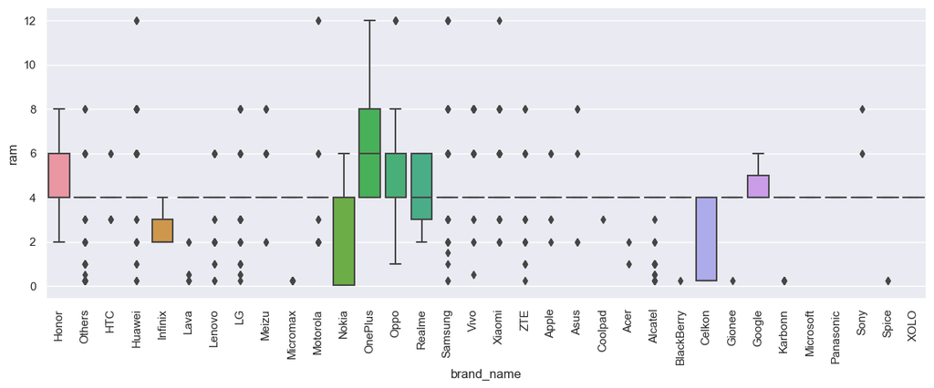

```python
plt.figure(figsize=(15, 5))
sns.boxplot(data=df, x="brand_name", y="ram")
plt.xticks(rotation=90)
plt.show()
```

```python
df_large_battery = df[df.battery > 4500]
df_large_battery.shape
```

```
(341, 15)
```

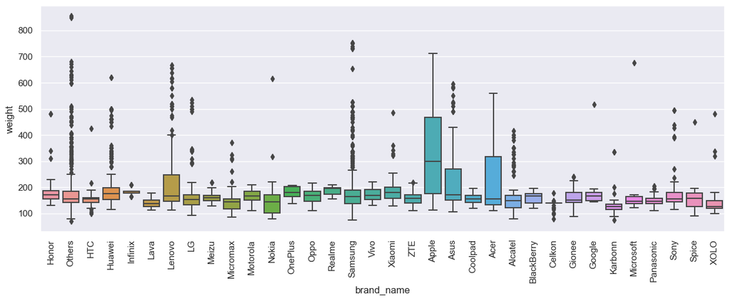

```python
plt.figure(figsize=(15, 5))
sns.boxplot(data=df, x="brand_name", y="weight")
plt.xticks(rotation=90)
plt.show()
```

**People who buy phones and tablets primarily for entertainment purposes prefer a large screen as they offer a better viewing experience. Let's create a new dataframe of only those devices which are suitable for such people and analyze.**

```python
df_large_screen = df[df.screen_size > 6 * 2.54]
df_large_screen.shape
```

```
(1099, 15)
```

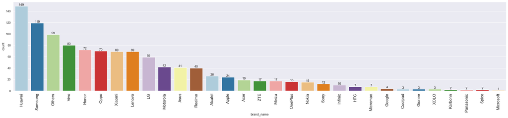

```python
labeled_barplot(
    df_large_screen, "brand_name"
)  ## create labeled_barplot for 'brand_name' in large screen datafram
```

**Everyone likes a good camera to capture their favorite moments with loved ones. Some customers specifically look for good front cameras to click cool selfies. Let's create a new dataframe of only those devices which are suitable for this customer segment and analyze.**

```python
df_selfie_camera = df[df.selfie_camera_mp > 8]
df_selfie_camera.shape
```

```
(655, 15)
```

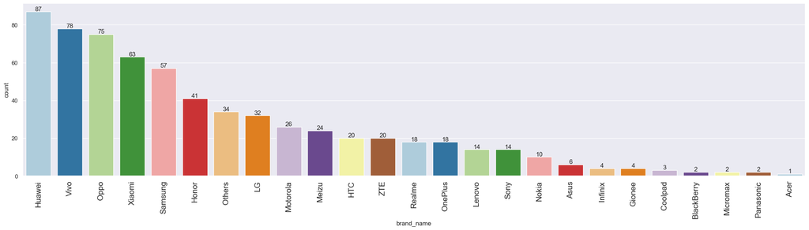

```python
labeled_barplot(
    df_selfie_camera, "brand_name"
)  ## create labeled_barplot for 'brand_name' in high selfie camera dataframe
```

**Let's do a similar analysis for rear cameras.**

- Rear cameras generally have a better resolution than front cameras, so we set the threshold higher for them at 16MP.

```python
df_main_camera = df[df.main_camera_mp > 16]
df_main_camera.shape
```

```
(94, 15)
```

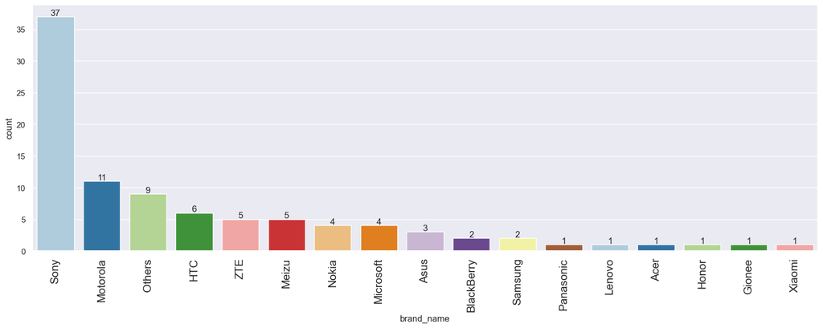

```python
labeled_barplot(
    df_main_camera, "brand_name"
)  ## create labeled_barplot for 'brand_name' in high main camera dataframe
```

**Let's see how the price of used devices varies across the years.**

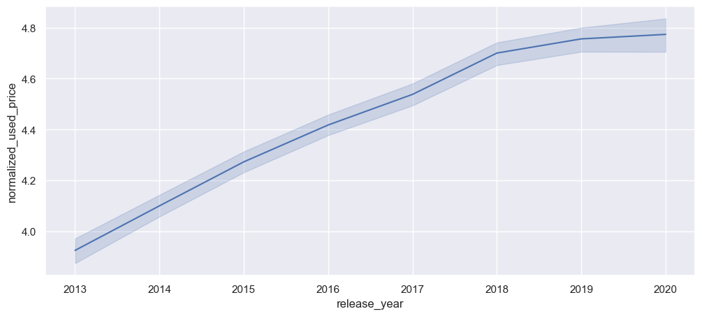

```python
plt.figure(figsize=(12, 5))
sns.lineplot(
    data=df, x="release_year", y="normalized_used_price"
)  ##create a lineplot for release year and used price
plt.show()
```

**Let's check how the prices vary for used phones and tablets offering 4G and 5G networks.**

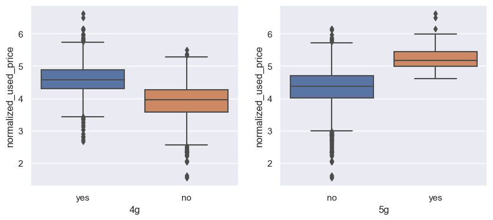

```python
plt.figure(figsize=(10, 4))

plt.subplot(121)
sns.boxplot(data=df, x="4g", y="normalized_used_price")

plt.subplot(122)
sns.boxplot(data=df, x="5g", y="normalized_used_price")

plt.show()
```

## Data Preprocessing

- Missing value treatment
- Feature engineering (if needed)
- Outlier detection and treatment (if needed)
- Preparing data for modeling
- Any other preprocessing steps (if needed)

### Missing Value Imputation

- We will impute the missing values in the data by the column medians grouped by `release_year` and `brand_name`.

```python
# let's create a copy of the data
df1 = df.copy()
```

```python
## checking for missing values
df1.isnull()
```

|  | brand_name | os | screen_size | 4g | 5g | main_camera_mp | selfie_camera_mp | int_memory | ram | battery | weight | release_year | days_used | normalized_used_price | normalized_new_price |
| --- | --- | --- | --- | --- | --- | --- | --- | --- | --- | --- | --- | --- | --- | --- | --- |
| 0 | False | False | False | False | False | False | False | False | False | False | False | False | False | False | False |
| 1 | False | False | False | False | False | False | False | False | False | False | False | False | False | False | False |
| 2 | False | False | False | False | False | False | False | False | False | False | False | False | False | False | False |
| 3 | False | False | False | False | False | False | False | False | False | False | False | False | False | False | False |
| 4 | False | False | False | False | False | False | False | False | False | False | False | False | False | False | False |
| ... | ... | ... | ... | ... | ... | ... | ... | ... | ... | ... | ... | ... | ... | ... | ... |
| 3449 | False | False | False | False | False | True | False | False | False | False | False | False | False | False | False |
| 3450 | False | False | False | False | False | False | False | False | False | False | False | False | False | False | False |
| 3451 | False | False | False | False | False | False | False | False | False | False | False | False | False | False | False |
| 3452 | False | False | False | False | False | False | False | False | False | False | False | False | False | False | False |
| 3453 | False | False | False | False | False | False | False | False | False | False | False | False | False | False | False |

3454 rows × 15 columns

```python
cols_impute = [
    "main_camera_mp",
    "selfie_camera_mp",
    "int_memory",
    "ram",
    "battery",
    "weight",
]

for col in cols_impute:
    df1[col] = df1[col].fillna(
        value=df1.groupby(["release_year", "brand_name"])[col].transform("median")
    )  ## Impute missing values in cols_impute with median by grouping the data on release year and brand name

# checking for missing values
df1.isnull()  ## Check missing values after imputing the above columns
```

|  | brand_name | os | screen_size | 4g | 5g | main_camera_mp | selfie_camera_mp | int_memory | ram | battery | weight | release_year | days_used | normalized_used_price | normalized_new_price |
| --- | --- | --- | --- | --- | --- | --- | --- | --- | --- | --- | --- | --- | --- | --- | --- |
| 0 | False | False | False | False | False | False | False | False | False | False | False | False | False | False | False |
| 1 | False | False | False | False | False | False | False | False | False | False | False | False | False | False | False |
| 2 | False | False | False | False | False | False | False | False | False | False | False | False | False | False | False |
| 3 | False | False | False | False | False | False | False | False | False | False | False | False | False | False | False |
| 4 | False | False | False | False | False | False | False | False | False | False | False | False | False | False | False |
| ... | ... | ... | ... | ... | ... | ... | ... | ... | ... | ... | ... | ... | ... | ... | ... |
| 3449 | False | False | False | False | False | True | False | False | False | False | False | False | False | False | False |
| 3450 | False | False | False | False | False | False | False | False | False | False | False | False | False | False | False |
| 3451 | False | False | False | False | False | False | False | False | False | False | False | False | False | False | False |
| 3452 | False | False | False | False | False | False | False | False | False | False | False | False | False | False | False |
| 3453 | False | False | False | False | False | False | False | False | False | False | False | False | False | False | False |

3454 rows × 15 columns

```python
# Fill the missing values in the 'main_camera_mp' column with the median
df1["main_camera_mp"] = df1["main_camera_mp"].fillna(df1["main_camera_mp"].median())

# Checking for missing values
df1.isnull().sum()  ## Check missing values after imputing the above columns
```

```
brand_name               0
os                       0
screen_size              0
4g                       0
5g                       0
main_camera_mp           0
selfie_camera_mp         2
int_memory               0
ram                      0
battery                  6
weight                   7
release_year             0
days_used                0
normalized_used_price    0
normalized_new_price     0
dtype: int64
```

```python
# Fill the missing values in the 'main_camera_mp' column with the median
df1["selfie_camera_mp"] = df1["selfie_camera_mp"].fillna(
    df1["selfie_camera_mp"].median()
)
```

```python
df1["battery"] = df1["battery"].fillna(df1["battery"].median())
```

```python
df1["weight"] = df1["weight"].fillna(df1["weight"].median())

df1.isnull().sum()  ## Check missing values after imputing the above columns
```

```
brand_name               0
os                       0
screen_size              0
4g                       0
5g                       0
main_camera_mp           0
selfie_camera_mp         0
int_memory               0
ram                      0
battery                  0
weight                   0
release_year             0
days_used                0
normalized_used_price    0
normalized_new_price     0
dtype: int64
```

### Feature Engineering

- Let's create a new column `years_since_release` from the `release_year` column.
- We will consider the year of data collection, 2021, as the baseline.
- We will drop the `release_year` column.

```python
df1["years_since_release"] = 2021 - df1["release_year"]
df1.drop("release_year", axis=1, inplace=True)
df1["years_since_release"].describe()
```

```
count    3454.000000
mean        5.034742
std         2.298455
min         1.000000
25%         3.000000
50%         5.500000
75%         7.000000
max         8.000000
Name: years_since_release, dtype: float64
```

### Outlier Check

- Let's check for outliers in the data.

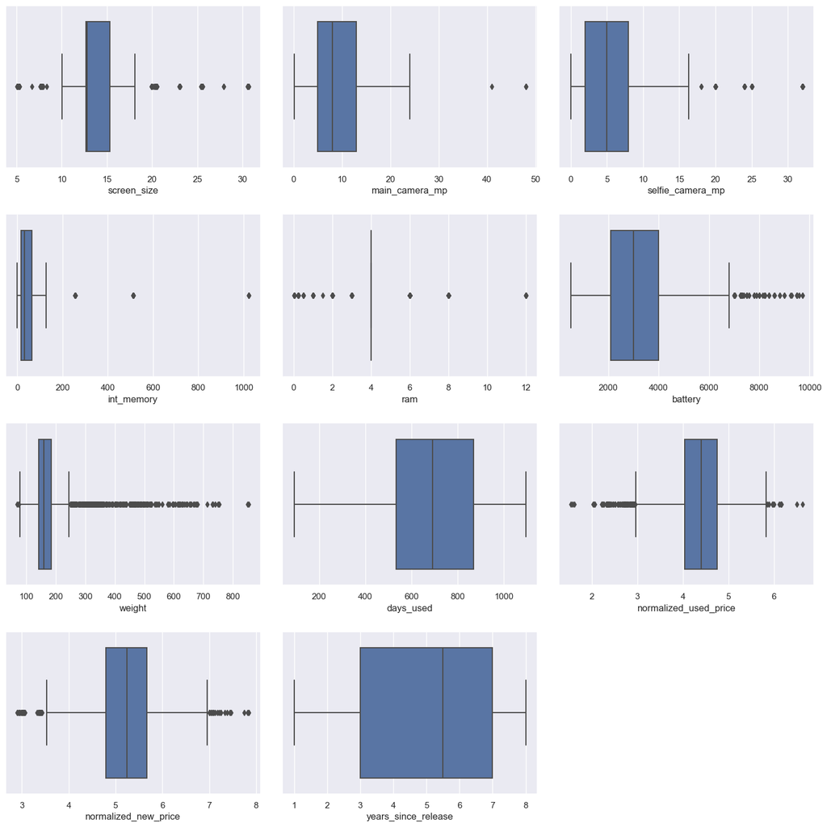

```python
# outlier detection using boxplot
num_cols = df1.select_dtypes(include=np.number).columns.tolist()

plt.figure(figsize=(15, 15))

for i, variable in enumerate(num_cols):
    plt.subplot(4, 3, i + 1)
    sns.boxplot(data=df1, x=variable)
    plt.tight_layout(pad=2)

plt.show()
```

## EDA

- It is a good idea to explore the data once again after manipulating it.
- We want to predict the normalized price of used devices
- Before we proceed to build a model, we'll have to encode categorical features
- We'll split the data into train and test to be able to evaluate the model that we build on the train data
- We will build a Linear Regression model using the train data and then check it's performance

```python
# Define the independent variables (excluding the target variable)
X = df1.drop("normalized_used_price", axis=1)

# Define the dependent variable, which is the normalized price of the used/refurbished device
y = df1["normalized_used_price"]

print(X.head())
print()
print(y.head())
```

```
  brand_name       os  screen_size   4g   5g  main_camera_mp  \
0      Honor  Android        14.50  yes   no            13.0
1      Honor  Android        17.30  yes  yes            13.0
2      Honor  Android        16.69  yes  yes            13.0
3      Honor  Android        25.50  yes  yes            13.0
4      Honor  Android        15.32  yes   no            13.0

   selfie_camera_mp  int_memory  ram  battery  weight  days_used  \
0               5.0        64.0  3.0   3020.0   146.0        127
1              16.0       128.0  8.0   4300.0   213.0        325
2               8.0       128.0  8.0   4200.0   213.0        162
3               8.0        64.0  6.0   7250.0   480.0        345
4               8.0        64.0  3.0   5000.0   185.0        293

   normalized_new_price  years_since_release
0              4.715100                    1
1              5.519018                    1
2              5.884631                    1
3              5.630961                    1
4              4.947837                    1

0    4.307572
1    5.162097
2    5.111084
3    5.135387
4    4.389995
Name: normalized_used_price, dtype: float64
```

```python
# let's add the intercept to data
X = sm.add_constant(X)
```

```python
# creating dummy variables
X = pd.get_dummies(
    X,
    columns=X.select_dtypes(include=["object", "category"]).columns.tolist(),
    drop_first=True,
)  ## code to create dummies for independent features

X.head()
```

|  | const | screen_size | main_camera_mp | selfie_camera_mp | int_memory | ram | battery | weight | days_used | normalized_new_price | ... | brand_name_Spice | brand_name_Vivo | brand_name_XOLO | brand_name_Xiaomi | brand_name_ZTE | os_Others | os_Windows | os_iOS | 4g_yes | 5g_yes |
| --- | --- | --- | --- | --- | --- | --- | --- | --- | --- | --- | --- | --- | --- | --- | --- | --- | --- | --- | --- | --- | --- |
| 0 | 1.0 | 14.50 | 13.0 | 5.0 | 64.0 | 3.0 | 3020.0 | 146.0 | 127 | 4.715100 | ... | 0 | 0 | 0 | 0 | 0 | 0 | 0 | 0 | 1 | 0 |
| 1 | 1.0 | 17.30 | 13.0 | 16.0 | 128.0 | 8.0 | 4300.0 | 213.0 | 325 | 5.519018 | ... | 0 | 0 | 0 | 0 | 0 | 0 | 0 | 0 | 1 | 1 |
| 2 | 1.0 | 16.69 | 13.0 | 8.0 | 128.0 | 8.0 | 4200.0 | 213.0 | 162 | 5.884631 | ... | 0 | 0 | 0 | 0 | 0 | 0 | 0 | 0 | 1 | 1 |
| 3 | 1.0 | 25.50 | 13.0 | 8.0 | 64.0 | 6.0 | 7250.0 | 480.0 | 345 | 5.630961 | ... | 0 | 0 | 0 | 0 | 0 | 0 | 0 | 0 | 1 | 1 |
| 4 | 1.0 | 15.32 | 13.0 | 8.0 | 64.0 | 3.0 | 5000.0 | 185.0 | 293 | 4.947837 | ... | 0 | 0 | 0 | 0 | 0 | 0 | 0 | 0 | 1 | 0 |

5 rows × 49 columns

```python
# splitting the data in 70:30 ratio for train to test data
x_train, x_test, y_train, y_test = train_test_split(
    X, y, test_size=0.3, random_state=42
)  ## code to split the data into train and test in specified ratio
```

```python
print("Number of rows in train data =", x_train.shape[0])
print("Number of rows in test data =", x_test.shape[0])
```

```
Number of rows in train data = 2417
Number of rows in test data = 1037
```

## Model Building - Linear Regression

```python
## check for missing or infinite values:
print(x_train.isnull().sum())
print(np.isinf(x_train).sum())
```

```
const                    0
screen_size              0
main_camera_mp           0
selfie_camera_mp         0
int_memory               0
ram                      0
battery                  0
weight                   0
days_used                0
normalized_new_price     0
years_since_release      0
brand_name_Alcatel       0
brand_name_Apple         0
brand_name_Asus          0
brand_name_BlackBerry    0
brand_name_Celkon        0
brand_name_Coolpad       0
brand_name_Gionee        0
brand_name_Google        0
brand_name_HTC           0
brand_name_Honor         0
brand_name_Huawei        0
brand_name_Infinix       0
brand_name_Karbonn       0
brand_name_LG            0
brand_name_Lava          0
brand_name_Lenovo        0
brand_name_Meizu         0
brand_name_Micromax      0
brand_name_Microsoft     0
brand_name_Motorola      0
brand_name_Nokia         0
brand_name_OnePlus       0
brand_name_Oppo          0
brand_name_Others        0
brand_name_Panasonic     0
brand_name_Realme        0
brand_name_Samsung       0
brand_name_Sony          0
brand_name_Spice         0
```

[output cut: 45 more lines]

```
brand_name_Panasonic     0
brand_name_Realme        0
brand_name_Samsung       0
brand_name_Sony          0
brand_name_Spice         0
brand_name_Vivo          0
brand_name_XOLO          0
brand_name_Xiaomi        0
brand_name_ZTE           0
os_Others                0
os_Windows               0
os_iOS                   0
4g_yes                   0
5g_yes                   0
dtype: int64
```

```python
olsmodel1 = sm.OLS(y_train, x_train).fit()  ## code to fit OLS model
print(olsmodel1.summary())
```

```
                              OLS Regression Results
=================================================================================
Dep. Variable:     normalized_used_price   R-squared:                       0.848
Model:                               OLS   Adj. R-squared:                  0.845
Method:                    Least Squares   F-statistic:                     276.3
Date:                   Wed, 02 Aug 2023   Prob (F-statistic):               0.00
Time:                           08:20:15   Log-Likelihood:                 121.92
No. Observations:                   2417   AIC:                            -145.8
Df Residuals:                       2368   BIC:                             137.9
Df Model:                             48
Covariance Type:               nonrobust
=========================================================================================
                            coef    std err          t      P>|t|      [0.025      0.975]
-----------------------------------------------------------------------------------------
const                     1.4299      0.072     19.785      0.000       1.288       1.572
screen_size               0.0292      0.004      8.241      0.000       0.022       0.036
main_camera_mp            0.0223      0.002     14.618      0.000       0.019       0.025
selfie_camera_mp          0.0118      0.001     10.018      0.000       0.009       0.014
int_memory                0.0002   6.77e-05      2.670      0.008     4.8e-05       0.000
ram                       0.0314      0.005      5.957      0.000       0.021       0.042
battery               -1.469e-05   7.35e-06     -2.000      0.046   -2.91e-05   -2.88e-07
weight                    0.0008      0.000      5.867      0.000       0.001       0.001
days_used              2.648e-05   3.08e-05      0.860      0.390   -3.39e-05    8.68e-05
normalized_new_price      0.4116      0.012     33.542      0.000       0.388       0.436
years_since_release      -0.0268      0.005     -5.873      0.000      -0.036      -0.018
brand_name_Alcatel       -0.0810      0.050     -1.628      0.104      -0.179       0.017
brand_name_Apple         -0.0540      0.148     -0.365      0.715      -0.344       0.236
brand_name_Asus           0.0115      0.049      0.233      0.816      -0.085       0.108
brand_name_BlackBerry     0.0312      0.072      0.434      0.665      -0.110       0.173
brand_name_Celkon        -0.2339      0.068     -3.433      0.001      -0.368      -0.100
brand_name_Coolpad       -0.0180      0.071     -0.253      0.800      -0.157       0.121
brand_name_Gionee        -0.0129      0.059     -0.220      0.826      -0.128       0.102
brand_name_Google        -0.1207      0.083     -1.458      0.145      -0.283       0.042
brand_name_HTC           -0.0388      0.050     -0.774      0.439      -0.137       0.059
brand_name_Honor         -0.0559      0.051     -1.099      0.272      -0.156       0.044
brand_name_Huawei        -0.0658      0.046     -1.425      0.154      -0.156       0.025
brand_name_Infinix        0.1231      0.114      1.084      0.279      -0.100       0.346
brand_name_Karbonn       -0.0564      0.068     -0.826      0.409      -0.190       0.078
brand_name_LG            -0.0643      0.047     -1.373      0.170      -0.156       0.028
brand_name_Lava          -0.0220      0.063     -0.348      0.728      -0.146       0.102
```

[output cut: 19 more lines]

```
os_Windows               -0.0316      0.043     -0.727      0.467      -0.117       0.054
os_iOS                   -0.0046      0.148     -0.031      0.975      -0.295       0.286
4g_yes                    0.0388      0.016      2.394      0.017       0.007       0.071
5g_yes                   -0.0601      0.033     -1.847      0.065      -0.124       0.004
==============================================================================
Omnibus:                      235.262   Durbin-Watson:                   1.991
Prob(Omnibus):                  0.000   Jarque-Bera (JB):              636.809
Skew:                          -0.536   Prob(JB):                    5.23e-139
Kurtosis:                       5.275   Cond. No.                     1.85e+05
==============================================================================

Notes:
[1] Standard Errors assume that the covariance matrix of the errors is correctly specified.
[2] The condition number is large, 1.85e+05. This might indicate that there are
strong multicollinearity or other numerical problems.
```

- Overall, the model appears to have a strong explanatory power for the normalized used price, with certain technical specifications like screen size, camera quality, and RAM playing significant roles. However, the brand names seem less impactful in this model, and the potential issue of multicollinearity may warrant further investigation.

## Model Performance Check

**Let's check the performance of the model using different metrics.**

- We will be using metric functions defined in sklearn for RMSE, MAE, and $R^2$.
- We will define a function to calculate MAPE and adjusted $R^2$.
- We will create a function which will print out all the above metrics in one go.

```python
# function to compute adjusted R-squared
def adj_r2_score(predictors, targets, predictions):
    r2 = r2_score(targets, predictions)
    n = predictors.shape[0]
    k = predictors.shape[1]
    return 1 - ((1 - r2) * (n - 1) / (n - k - 1))


# function to compute MAPE
def mape_score(targets, predictions):
    return np.mean(np.abs(targets - predictions) / targets) * 100


# function to compute different metrics to check performance of a regression model
def model_performance_regression(model, predictors, target):
    """
    Function to compute different metrics to check regression model performance

    model: regressor
    predictors: independent variables
    target: dependent variable
    """

    # predicting using the independent variables
    pred = model.predict(predictors)

    r2 = r2_score(target, pred)  # to compute R-squared
    adjr2 = adj_r2_score(predictors, target, pred)  # to compute adjusted R-squared
    rmse = np.sqrt(mean_squared_error(target, pred))  # to compute RMSE
    mae = mean_absolute_error(target, pred)  # to compute MAE
    mape = mape_score(target, pred)  # to compute MAPE

    # creating a dataframe of metrics
    df_perf = pd.DataFrame(
        {
            "RMSE": rmse,
            "MAE": mae,
            "R-squared": r2,
            "Adj. R-squared": adjr2,
            "MAPE": mape,
        },
        index=[0],
    )

    return df_perf
```

```python
# checking model performance on train set (seen 70% data)
print("Training Performance\n")
olsmodel1_train_perf = model_performance_regression(olsmodel1, x_train, y_train)
olsmodel1_train_perf
```

```
Training Performance
```

|  | RMSE | MAE | R-squared | Adj. R-squared | MAPE |
| --- | --- | --- | --- | --- | --- |
| 0 | 0.230068 | 0.178415 | 0.848482 | 0.845345 | 4.291187 |

```python
print("Test Performance\n")
olsmodel1_test_perf = model_performance_regression(
    olsmodel1, x_test, y_test
)  # Complete the code to check the performance on test data
olsmodel1_test_perf
```

```
Test Performance
```

|  | RMSE | MAE | R-squared | Adj. R-squared | MAPE |
| --- | --- | --- | --- | --- | --- |
| 0 | 0.238089 | 0.188194 | 0.833538 | 0.825274 | 4.503704 |

**Insights:**

- The model seems to perform well on both training and test datasets, with similar metrics across both sets. This suggests that the model is neither overfitting nor underfitting.
- The difference between the training and test performance is not very large, indicating good generalization. However, I may want to consider looking into the specific variables and their relationships to see if there are ways to improve the model further.

## Checking Linear Regression Assumptions

- In order to make statistical inferences from a linear regression model, it is important to ensure that the assumptions of linear regression are satisfied.

We will be checking the following Linear Regression assumptions:

1. **No Multicollinearity**
2. **Linearity of variables**
3. **Independence of error terms**
4. **Normality of error terms**
5. **No Heteroscedasticity**

### TEST FOR MULTICOLLINEARITY

- We will test for multicollinearity using VIF.

```python
# Let's define a function to check VIF.


def checking_vif(predictors):
    vif = pd.DataFrame()
    vif["feature"] = predictors.columns

    # calculating VIF for each feature
    vif["VIF"] = [
        variance_inflation_factor(predictors.values, i)
        for i in range(len(predictors.columns))
    ]
    return vif
```

```python
checking_vif(x_train)
```

|  | feature | VIF |
| --- | --- | --- |
| 0 | const | 233.663544 |
| 1 | screen_size | 8.264446 |
| 2 | main_camera_mp | 2.262627 |
| 3 | selfie_camera_mp | 2.870720 |
| 4 | int_memory | 1.361873 |
| 5 | ram | 2.288543 |
| 6 | battery | 4.050736 |
| 7 | weight | 6.405556 |
| 8 | days_used | 2.592137 |
| 9 | normalized_new_price | 3.219739 |
| 10 | years_since_release | 4.862990 |
| 11 | brand_name_Alcatel | 3.458600 |
| 12 | brand_name_Apple | 11.196993 |
| 13 | brand_name_Asus | 3.651283 |
| 14 | brand_name_BlackBerry | 1.623343 |
| 15 | brand_name_Celkon | 1.873204 |
| 16 | brand_name_Coolpad | 1.574473 |
| 17 | brand_name_Gionee | 2.076751 |
| 18 | brand_name_Google | 1.388610 |
| 19 | brand_name_HTC | 3.460211 |
| 20 | brand_name_Honor | 3.565771 |
| 21 | brand_name_Huawei | 6.397642 |
| 22 | brand_name_Infinix | 1.191609 |
| 23 | brand_name_Karbonn | 1.628485 |
| 24 | brand_name_LG | 5.353144 |
| 25 | brand_name_Lava | 1.825993 |
| 26 | brand_name_Lenovo | 4.705690 |
| 27 | brand_name_Meizu | 2.408898 |
| 28 | brand_name_Micromax | 3.779667 |
| 29 | brand_name_Microsoft | 2.093116 |
| 30 | brand_name_Motorola | 3.477257 |
| 31 | brand_name_Nokia | 3.753090 |
| 32 | brand_name_OnePlus | 1.587917 |
| 33 | brand_name_Oppo | 4.286919 |
| 34 | brand_name_Others | 10.834354 |
| 35 | brand_name_Panasonic | 1.890615 |
| 36 | brand_name_Realme | 1.965737 |
| 37 | brand_name_Samsung | 8.012873 |
| 38 | brand_name_Sony | 2.879356 |
| 39 | brand_name_Spice | 1.638397 |
| 40 | brand_name_Vivo | 3.731710 |
| 41 | brand_name_XOLO | 2.161408 |
| 42 | brand_name_Xiaomi | 4.077455 |
| 43 | brand_name_ZTE | 4.341289 |
| 44 | os_Others | 1.886553 |
| 45 | os_Windows | 1.741706 |
| 46 | os_iOS | 10.041011 |
| 47 | 4g_yes | 2.555389 |
| 48 | 5g_yes | 1.843183 |

```python
### Explore Removing Multicollinearity (if needed)
```

```python
def treating_multicollinearity(predictors, target, high_vif_columns):
    """
    Checking the effect of dropping the columns showing high multicollinearity
    on model performance (adj. R-squared and RMSE)

    predictors: independent variables
    target: dependent variable
    high_vif_columns: columns having high VIF
    """
    # empty lists to store adj. R-squared and RMSE values
    adj_r2 = []
    rmse = []

    # build ols models by dropping one of the high VIF columns at a time
    # store the adjusted R-squared and RMSE in the lists defined previously
    for cols in high_vif_columns:
        # defining the new train set
        train = predictors.loc[:, ~predictors.columns.str.startswith(cols)]

        # create the model
        olsmodel = sm.OLS(target, train).fit()

        # adding adj. R-squared and RMSE to the lists
        adj_r2.append(olsmodel.rsquared_adj)
        rmse.append(np.sqrt(olsmodel.mse_resid))

    # creating a dataframe for the results
    temp = pd.DataFrame(
        {
            "col": high_vif_columns,
            "Adj. R-squared after_dropping col": adj_r2,
            "RMSE after dropping col": rmse,
        }
    ).sort_values(by="Adj. R-squared after_dropping col", ascending=False)
    temp.reset_index(drop=True, inplace=True)

    return temp
```

```python
col_list = [
    "const",
    "screen_size",
    "brand_name_Apple",
    "brand_name_Others",
    "os_iOS",
    "brand_name_Samsung",
]  ## columns with high VIF

res = treating_multicollinearity(
    x_train, y_train, col_list
)  ## Assuming x_train contains the predictor variables
res
```

|  | col | Adj. R-squared after_dropping col | RMSE after dropping col |
| --- | --- | --- | --- |
| 0 | const | 0.996752 | 0.250861 |
| 1 | os_iOS | 0.845476 | 0.232387 |
| 2 | brand_name_Apple | 0.845467 | 0.232394 |
| 3 | brand_name_Samsung | 0.845342 | 0.232487 |
| 4 | brand_name_Others | 0.845315 | 0.232508 |
| 5 | screen_size | 0.841045 | 0.235696 |

- Given the business context and objective, these variables appear to be relevant, and dropping them may result in a loss of information that could affect the predictive accuracy of the model.

### Exploring Dropping high p-value variables

```python
# initial list of columns
predictors = (
    x_train.copy()
)  # Assuming x_train is the dataset containing your predictor variables
cols = predictors.columns.tolist()

# setting an initial max p-value
max_p_value = 1

while len(cols) > 0:
    # defining the train set
    x_train_aux = predictors[cols]

    # fitting the model
    model = sm.OLS(y_train, x_train_aux).fit()

    # getting the p-values and the maximum p-value
    p_values = model.pvalues
    max_p_value = max(p_values)

    # name of the variable with maximum p-value
    feature_with_p_max = p_values.idxmax()

    if max_p_value > 0.05:
        cols.remove(feature_with_p_max)
    else:
        break

selected_features = cols
print(selected_features)
```

```
['const', 'screen_size', 'main_camera_mp', 'selfie_camera_mp', 'int_memory', 'ram', 'weight', 'normalized_new_price', 'years_since_release', 'brand_name_Asus', 'brand_name_Celkon', 'brand_name_Nokia', 'brand_name_Xiaomi', 'os_Others', '4g_yes']
```

```python
x_train3 = x_train[
    selected_features
]  ## code to specify the train data from which to select the specified columns
x_test3 = x_test[
    selected_features
]  ## code to specify the test data from which to select the specified columns
```

```python
olsmodel2 = sm.OLS(
    y_train, x_train3
).fit()  ## code fit OLS() on updated dataset (no multicollinearity and no insignificant predictors)
print(olsmodel2.summary())
```

```
                              OLS Regression Results
=================================================================================
Dep. Variable:     normalized_used_price   R-squared:                       0.846
Model:                               OLS   Adj. R-squared:                  0.845
Method:                    Least Squares   F-statistic:                     945.1
Date:                   Wed, 02 Aug 2023   Prob (F-statistic):               0.00
Time:                           08:20:16   Log-Likelihood:                 105.12
No. Observations:                   2417   AIC:                            -180.2
Df Residuals:                       2402   BIC:                            -93.39
Df Model:                             14
Covariance Type:               nonrobust
========================================================================================
                           coef    std err          t      P>|t|      [0.025      0.975]
----------------------------------------------------------------------------------------
const                    1.4095      0.051     27.511      0.000       1.309       1.510
screen_size              0.0272      0.003      8.241      0.000       0.021       0.034
main_camera_mp           0.0225      0.001     16.032      0.000       0.020       0.025
selfie_camera_mp         0.0122      0.001     10.932      0.000       0.010       0.014
int_memory               0.0002   6.62e-05      2.486      0.013    3.48e-05       0.000
ram                      0.0259      0.005      5.682      0.000       0.017       0.035
weight                   0.0007      0.000      5.727      0.000       0.000       0.001
normalized_new_price     0.4054      0.011     36.629      0.000       0.384       0.427
years_since_release     -0.0217      0.004     -6.108      0.000      -0.029      -0.015
brand_name_Asus          0.0652      0.026      2.506      0.012       0.014       0.116
brand_name_Celkon       -0.1898      0.053     -3.558      0.000      -0.294      -0.085
brand_name_Nokia         0.0773      0.030      2.614      0.009       0.019       0.135
brand_name_Xiaomi        0.0827      0.025      3.292      0.001       0.033       0.132
os_Others               -0.0720      0.030     -2.418      0.016      -0.130      -0.014
4g_yes                   0.0427      0.015      2.826      0.005       0.013       0.072
==============================================================================
Omnibus:                      235.114   Durbin-Watson:                   1.992
Prob(Omnibus):                  0.000   Jarque-Bera (JB):              640.294
Skew:                          -0.533   Prob(JB):                    9.16e-140
Kurtosis:                       5.285   Cond. No.                     2.49e+03
==============================================================================

Notes:
[1] Standard Errors assume that the covariance matrix of the errors is correctly specified.
[2] The condition number is large, 2.49e+03. This might indicate that there are
strong multicollinearity or other numerical problems.
```

```python
# function to compute adjusted R-squared
def adj_r2_score(predictors, targets, predictions):
    r2 = r2_score(targets, predictions)
    n = predictors.shape[0]
    k = predictors.shape[1]
    return 1 - ((1 - r2) * (n - 1) / (n - k - 1))


# function to compute MAPE
def mape_score(targets, predictions):
    return np.mean(np.abs(targets - predictions) / targets) * 100


# function to compute different metrics to check performance of a regression model
def model_performance_regression(model, predictors, target):
    """
    Function to compute different metrics to check regression model performance

    model: regressor
    predictors: independent variables
    target: dependent variable
    """

    # predicting using the independent variables
    pred = model.predict(predictors)

    r2 = r2_score(target, pred)  # to compute R-squared
    adjr2 = adj_r2_score(predictors, target, pred)  # to compute adjusted R-squared
    rmse = np.sqrt(mean_squared_error(target, pred))  # to compute RMSE
    mae = mean_absolute_error(target, pred)  # to compute MAE
    mape = mape_score(target, pred)  # to compute MAPE

    # creating a dataframe of metrics
    df_perf = pd.DataFrame(
        {
            "RMSE": rmse,
            "MAE": mae,
            "R-squared": r2,
            "Adj. R-squared": adjr2,
            "MAPE": mape,
        },
        index=[0],
    )

    return df_perf
```

```python
print("Training Performance\n")
olsmodel2_train_perf = model_performance_regression(olsmodel2, x_train3, y_train)
olsmodel2_train_perf
```

```
Training Performance
```

|  | RMSE | MAE | R-squared | Adj. R-squared | MAPE |
| --- | --- | --- | --- | --- | --- |
| 0 | 0.231672 | 0.180014 | 0.846361 | 0.845402 | 4.334723 |

```python
print("Test Performance\n")
olsmodel2_test_perf = model_performance_regression(
    olsmodel2, x_test3, y_test
)  # Complete the code to check the performance on test data
olsmodel2_test_perf
```

```
Test Performance
```

|  | RMSE | MAE | R-squared | Adj. R-squared | MAPE |
| --- | --- | --- | --- | --- | --- |
| 0 | 0.237506 | 0.188132 | 0.834353 | 0.831919 | 4.504197 |

- Overall, this model's performance on the unseen data looks promising, aligning well with the training data and demonstrating a strong predictive ability. It seems well-suited to my business context of developing a dynamic pricing strategy for used and refurbished devices, as it has identified features that significantly influence the price and can predict the price with reasonable accuracy. It would be beneficial to keep monitoring the model's performance as it's deployed and updated with new data, to ensure that it continues to perform well.

**Now we'll check the rest of the assumptions on *olsmod2*.**

1. **Linearity of variables**
2. **Independence of error terms**
3. **Normality of error terms**
4. **No Heteroscedasticity**

### TEST FOR LINEARITY AND INDEPENDENCE

- We will test for linearity and independence by making a plot of fitted values vs residuals and checking for patterns.
- If there is no pattern, then we say the model is linear and residuals are independent.
- Otherwise, the model is showing signs of non-linearity and residuals are not independent.

```python
# let us create a dataframe with actual, fitted and residual values
df_pred = pd.DataFrame()

df_pred["Actual Values"] = y_train  # actual values
df_pred["Fitted Values"] = olsmodel2.fittedvalues  # predicted values
df_pred["Residuals"] = olsmodel2.resid  # residuals

df_pred.head()
```

|  | Actual Values | Fitted Values | Residuals |
| --- | --- | --- | --- |
| 1744 | 4.261975 | 4.306921 | -0.044946 |
| 3141 | 4.175156 | 3.854308 | 0.320848 |
| 1233 | 4.117410 | 4.427009 | -0.309599 |
| 3046 | 3.782597 | 3.847463 | -0.064865 |
| 2649 | 3.981922 | 3.915048 | 0.066874 |

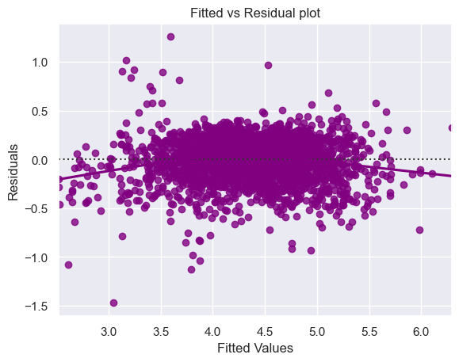

```python
# let's plot the fitted values vs residuals

sns.residplot(
    data=df_pred, x="Fitted Values", y="Residuals", color="purple", lowess=True
)
plt.xlabel("Fitted Values")
plt.ylabel("Residuals")
plt.title("Fitted vs Residual plot")
plt.show()
```

- perfectly random scatter would indicate that the model’s errors are random and the model is correctly specified for the data.

### TEST FOR NORMALITY

- We will test for normality by checking the distribution of residuals, by checking the Q-Q plot of residuals, and by using the Shapiro-Wilk test.
- If the residuals follow a normal distribution, they will make a straight line plot, otherwise not.
- If the p-value of the Shapiro-Wilk test is greater than 0.05, we can say the residuals are normally distributed.

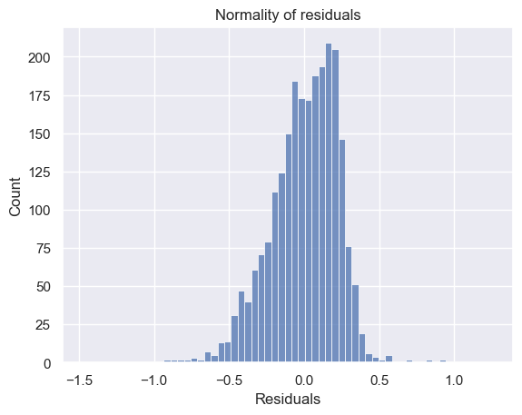

```python
sns.histplot(data=df_pred, x="Residuals")  # specify the column for residuals
plt.title("Normality of residuals")
plt.show()
```

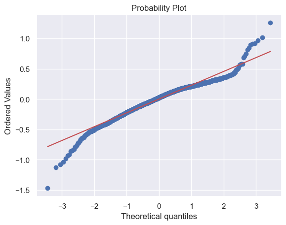

```python
import pylab
import scipy.stats as stats

stats.probplot(
    df_pred["Residuals"], dist="norm", plot=pylab
)  # Use the "Residuals" column from df_pred
plt.show()
```

```python
stats.shapiro(df_pred["Residuals"])  # Use the "Residuals" column from df_pred
```

```
ShapiroResult(statistic=0.9645523428916931, pvalue=6.483970029691279e-24)
```

### TEST FOR HOMOSCEDASTICITY

- We will test for homoscedasticity by using the goldfeldquandt test.
- If we get a p-value greater than 0.05, we can say that the residuals are homoscedastic. Otherwise, they are heteroscedastic.

```python
import statsmodels.stats.api as sms
from statsmodels.compat import lzip

name = ["F statistic", "p-value"]
test = sms.het_goldfeldquandt(df_pred["Residuals"], x_train3)
lzip(name, test)
```

```
[('F statistic', 0.9465463031048822), ('p-value', 0.8286027516595293)]
```

**Insights:**

- The result provides evidence that the residuals are homoscedastic, meaning that the variance of the residuals is approximately constant across different levels of the fitted values. This is a desirable property in a regression model as it fulfills one of the classical linear regression assumptions, and it suggests that my model's prediction errors are evenly distributed across different values of the predictors.
- Therefore, based on this test, it appears that my model is not violating the assumption of homoscedasticity, and this is a good sign for the validity and reliability of my regression analysis.

## Final Model

```python
olsmodel_final = sm.OLS(
    y_train, x_train3
).fit()  ## Assuming y_train is the dependent variable and x_train3 is the design matrix
print(olsmodel_final.summary())
```

```
                              OLS Regression Results
=================================================================================
Dep. Variable:     normalized_used_price   R-squared:                       0.846
Model:                               OLS   Adj. R-squared:                  0.845
Method:                    Least Squares   F-statistic:                     945.1
Date:                   Wed, 02 Aug 2023   Prob (F-statistic):               0.00
Time:                           08:20:17   Log-Likelihood:                 105.12
No. Observations:                   2417   AIC:                            -180.2
Df Residuals:                       2402   BIC:                            -93.39
Df Model:                             14
Covariance Type:               nonrobust
========================================================================================
                           coef    std err          t      P>|t|      [0.025      0.975]
----------------------------------------------------------------------------------------
const                    1.4095      0.051     27.511      0.000       1.309       1.510
screen_size              0.0272      0.003      8.241      0.000       0.021       0.034
main_camera_mp           0.0225      0.001     16.032      0.000       0.020       0.025
selfie_camera_mp         0.0122      0.001     10.932      0.000       0.010       0.014
int_memory               0.0002   6.62e-05      2.486      0.013    3.48e-05       0.000
ram                      0.0259      0.005      5.682      0.000       0.017       0.035
weight                   0.0007      0.000      5.727      0.000       0.000       0.001
normalized_new_price     0.4054      0.011     36.629      0.000       0.384       0.427
years_since_release     -0.0217      0.004     -6.108      0.000      -0.029      -0.015
brand_name_Asus          0.0652      0.026      2.506      0.012       0.014       0.116
brand_name_Celkon       -0.1898      0.053     -3.558      0.000      -0.294      -0.085
brand_name_Nokia         0.0773      0.030      2.614      0.009       0.019       0.135
brand_name_Xiaomi        0.0827      0.025      3.292      0.001       0.033       0.132
os_Others               -0.0720      0.030     -2.418      0.016      -0.130      -0.014
4g_yes                   0.0427      0.015      2.826      0.005       0.013       0.072
==============================================================================
Omnibus:                      235.114   Durbin-Watson:                   1.992
Prob(Omnibus):                  0.000   Jarque-Bera (JB):              640.294
Skew:                          -0.533   Prob(JB):                    9.16e-140
Kurtosis:                       5.285   Cond. No.                     2.49e+03
==============================================================================

Notes:
[1] Standard Errors assume that the covariance matrix of the errors is correctly specified.
[2] The condition number is large, 2.49e+03. This might indicate that there are
strong multicollinearity or other numerical problems.
```

```python
print("Training Performance\n")
olsmodel_final_train_perf = model_performance_regression(
    olsmodel_final, x_train3, y_train
)
olsmodel_final_train_perf
```

```
Training Performance
```

|  | RMSE | MAE | R-squared | Adj. R-squared | MAPE |
| --- | --- | --- | --- | --- | --- |
| 0 | 0.231672 | 0.180014 | 0.846361 | 0.845402 | 4.334723 |

```python
# checking model performance on test set (seen 30% data)
print("Test Performance\n")
olsmodel_final_test_perf = model_performance_regression(
    olsmodel_final, x_test3, y_test
)  ## code to check performance on test data
olsmodel_final_test_perf
```

```
Test Performance
```

|  | RMSE | MAE | R-squared | Adj. R-squared | MAPE |
| --- | --- | --- | --- | --- | --- |
| 0 | 0.237506 | 0.188132 | 0.834353 | 0.831919 | 4.504197 |

- Overall, the model seems to be performing well on the test set, with only slight differences in the metrics compared to the training set.
- The small differences between training and testing performance suggest that the model is not overfitting to the training data, which is a good sign. Overfitting would be indicated by significantly better performance on the training set compared to the test set.

## Actionable Insights and Recommendations

### Recommendations:

- Investigate Multicollinearity: We should keep an eye on the overlap between features to make sure it doesn’t become a problem. If needed, there are statistical tools and techniques to handle this issue.
- Business Insights: By understanding what drives the used price of mobile devices, the company can concentrate on those specific features that customers care about most. It's a roadmap for what matters in the market.
- Product Strategy: Understanding the factors that contribute to used price could inform product development and marketing strategies. Emphasizing key features in marketing or prioritizing certain specifications in new product development could align with customer preferences and market demands.
- Price Strategy: Knowledge of what affects used price can help in designing new products or marketing existing ones. Highlighting the right features can make products more appealing to customers.
- Monitoring and Updating: Continuously monitor the model's performance and update it with new data, especially if market trends and consumer preferences change.
- Comparison with Other Models: There's always room for improvement. Comparing this model with others can help find the best approach for the company's specific needs
- Interpretation and Implementation: Engage with business stakeholders to translate these technical insights into actionable business strategies. Make sure the interpretation of the model's coefficients is consistent with the business understanding.

**By following these recommendations, ReCell can not only optimize its pricing and product strategies but also gain deeper insights into the market and customer behavior.**